# PSY 653 Module 3: Nested Designs

# Set up contrasts

```r
contrasts(nested_demo$Hospital) <- c(-1, 1)
contrasts(nested_demo$Drug) <- c(-1,1)

cc1 <- c(-1, 1, 0, 0, 0, 0)
cc2 <- c(-1, 0, 1, 0, 0, 0)

cc3 <- c(0, 0, 0, -1, 1, 0)
cc4 <- c(0, 0, 0, -1, 0, 1)


contrasts(nested_demo$Condition) <- cbind(cc1, cc2, cc3, cc4)

str(nested_demo)
```

```
tibble [114 x 4] (S3: spec_tbl_df/tbl_df/tbl/data.frame)
 $ Y        : num [1:114] 5 6 9 9 10 12 13 7 8 3 ...
 $ Hospital : Factor w/ 2 levels "H1","H2": 1 1 1 1 1 1 1 1 1 1 ...
  ..- attr(*, "contrasts")= num [1:2, 1] -1 1
  .. ..- attr(*, "dimnames")=List of 2
  .. .. ..$ : chr [1:2] "H1" "H2"
  .. .. ..$ : NULL
 $ Drug     : Factor w/ 2 levels "D1","D2": 1 1 1 1 1 1 1 1 1 1 ...
  ..- attr(*, "contrasts")= num [1:2, 1] -1 1
  .. ..- attr(*, "dimnames")=List of 2
  .. .. ..$ : chr [1:2] "D1" "D2"
  .. .. ..$ : NULL
 $ Condition: Factor w/ 6 levels "C1","C2","C3",..: 1 1 1 1 1 1 1 1 1 2 ...
  ..- attr(*, "contrasts")= num [1:6, 1:5] -1 1 0 0 0 0 -1 0 1 0 ...
  .. ..- attr(*, "dimnames")=List of 2
  .. .. ..$ : chr [1:6] "C1" "C2" "C3" "C4" ...
  .. .. ..$ : chr [1:5] "cc1" "cc2" "cc3" "cc4" ...
 - attr(*, "spec")=
  .. cols(
  ..   Y = col_double(),
  ..   Hospital = col_character(),
  ..   Drug = col_character(),
  ..   Condition = col_character()
  .. )
```

```r
mod_contrast <- lm(Y~ Hospital + Drug + Drug/Condition + Hospital*Drug + Hospital*(Drug/Condition), data=nested_demo)
summary.lm(mod_contrast)
```

```
Call:
lm(formula = Y ~ Hospital + Drug + Drug/Condition + Hospital *
    Drug + Hospital * (Drug/Condition), data = nested_demo)

Residuals:
    Min      1Q  Median      3Q     Max
-5.6000 -1.7000  0.1667  2.1111  6.4444

Coefficients: (12 not defined because of singularities)
                               Estimate Std. Error t value Pr(>|t|)
(Intercept)                    8.746296   0.280670  31.162   <2e-16 ***
Hospital1                     -0.012963   0.280670  -0.046   0.9633
Drug1                         -0.007407   0.280670  -0.026   0.9790
DrugD1:Conditioncc1           -0.175926   0.561340  -0.313   0.7546
DrugD2:Conditioncc1                  NA         NA      NA       NA
DrugD1:Conditioncc2            0.040741   0.561340   0.073   0.9423
DrugD2:Conditioncc2                  NA         NA      NA       NA
DrugD1:Conditioncc3                  NA         NA      NA       NA
DrugD2:Conditioncc3            1.055556   0.561340   1.880   0.0629 .
DrugD1:Conditioncc4                  NA         NA      NA       NA
DrugD2:Conditioncc4           -0.944444   0.561340  -1.682   0.0955 .
DrugD1:Condition                     NA         NA      NA       NA
DrugD2:Condition                     NA         NA      NA       NA
Hospital1:Drug1               -0.025926   0.280670  -0.092   0.9266
Hospital1:DrugD1:Conditioncc1  0.009259   0.561340   0.016   0.9869
Hospital1:DrugD2:Conditioncc1        NA         NA      NA       NA
Hospital1:DrugD1:Conditioncc2 -0.107407   0.561340  -0.191   0.8486
Hospital1:DrugD2:Conditioncc2        NA         NA      NA       NA
Hospital1:DrugD1:Conditioncc3        NA         NA      NA       NA
Hospital1:DrugD2:Conditioncc3 -0.055556   0.561340  -0.099   0.9214
Hospital1:DrugD1:Conditioncc4        NA         NA      NA       NA
Hospital1:DrugD2:Conditioncc4 -0.055556   0.561340  -0.099   0.9214
Hospital1:DrugD1:Condition           NA         NA      NA       NA
Hospital1:DrugD2:Condition           NA         NA      NA       NA
---
Signif. codes:  0 ‘***’ 0.001 ‘**’ 0.01 ‘*’ 0.05 ‘.’ 0.1 ‘ ’ 1

Residual standard error: 2.993 on 102 degrees of freedom
Multiple R-squared:  0.04211,   Adjusted R-squared:  -0.06119
F-statistic: 0.4076 on 11 and 102 DF,  p-value: 0.9498
```

# Part 2: Try it Yourself

Factors (i.e., effects we can test with this model)  
Hospital (df=1)  
Drug within hospital (df=2; 1 for each hospital) Condition within drug within hospital (df=8; 2 for each drug in each hospital) Error (df = 114-11-1 = 102)

No interactions testable here, because the model is fully nested

## Read data

```r
nested_practice<-read_csv(file="Nested_practice.csv")
```

## Check how variables are read

```r
str(nested_practice)
```

```
tibble [114 x 4] (S3: spec_tbl_df/tbl_df/tbl/data.frame)
 $ Y        : num [1:114] 5 4 3 5 4 3 6 5 4 6 ...
 $ Hospital : chr [1:114] "H1" "H1" "H1" "H1" ...
 $ Drug     : chr [1:114] "D1" "D2" "D1" "D2" ...
 $ Condition: chr [1:114] "C01" "C02" "C03" "C04" ...
 - attr(*, "spec")=
  .. cols(
  ..   Y = col_double(),
  ..   Hospital = col_character(),
  ..   Drug = col_character(),
  ..   Condition = col_character()
  .. )
```

The three predictor variables (Hospital, Drug, and Condition) are all character variables, and the outcome variable (Y) is numeric.

```r
nested_practice <- mutate(nested_practice,
                      Hospital = as.factor(Hospital),
                      Drug = as.factor(Drug),
                      Condition = as.factor(Condition))
```

## Get variable descriptives

```r
psych::describe(nested_practice) #note: variables are characters (include text)
```

|  | vars | n | mean | sd | median | trimmed | mad | min | max | range | skew | kurtosis | se |
| --- | --- | --- | --- | --- | --- | --- | --- | --- | --- | --- | --- | --- | --- |
| Y | 1 | 114 | 8.75 | 2.91 | 9 | 8.79 | 2.97 | 3 | 15 | 12 | -0.14 | -0.71 | 0.27 |
| Hospital* | 2 | 114 | 1.53 | 0.50 | 2 | 1.53 | 0.00 | 1 | 2 | 1 | -0.10 | -2.01 | 0.05 |
| Drug* | 3 | 114 | 2.55 | 1.12 | 3 | 2.57 | 1.48 | 1 | 4 | 3 | -0.07 | -1.38 | 0.11 |
| Condition* | 4 | 114 | 6.66 | 3.46 | 7 | 6.68 | 4.45 | 1 | 12 | 11 | -0.07 | -1.24 | 0.32 |

## Calculate the mean values of Y by hospital, drug, and condition

```r
# the aggregate function shows us the mean value of Y across each level of the predictors.
aggregate(nested_practice$Y, by=list(Hospital=nested_practice$Hospital), mean)
```

| Hospital | x |
| --- | --- |
| H1 | 8.759259 |
| H2 | 8.733333 |

```r
aggregate(nested_practice$Y, by=list(Drug=nested_practice$Drug), mean)
```

| Drug | x |
| --- | --- |
| D1 | 8.740741 |
| D2 | 8.777778 |
| D3 | 8.766667 |
| D4 | 8.700000 |

```r
aggregate(nested_practice$Y, by=list(Condition=nested_practice$Condition), mean)
```

| Condition | x |
| --- | --- |
| C01 | 8.777778 |
| C02 | 8.555556 |
| C03 | 8.555556 |
| C04 | 9.888889 |
| C05 | 8.888889 |
| C06 | 7.888889 |
| C07 | 8.700000 |
| C08 | 7.700000 |
| C09 | 9.000000 |
| C10 | 8.700000 |

[output cut: 2 more lines]

The mean of Y is quite similar between the two hospitals and between the four drugs. The mean of Y varies a little more across the 12 treatment conditions, ranging from 7.70 to 9.89.

# Boxplots

## Y By Hospital

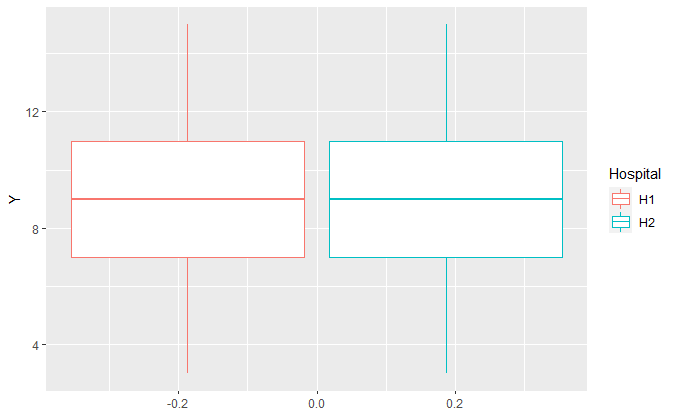

```r
ggplot(nested_practice, aes(y = Y, color = Hospital)) +
  geom_boxplot()
```

## Y By drug, faceted by Hospital

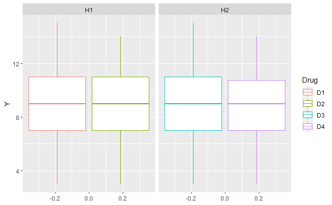

```r
ggplot(nested_practice, aes(y = Y, color = Drug)) +
  geom_boxplot() +
  facet_wrap(~Hospital)
```

## Y by condition faceted by hospital and drug

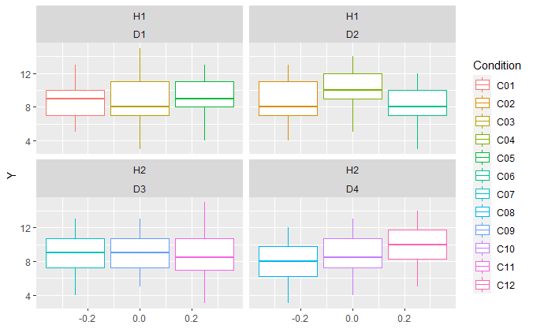

```r
ggplot(nested_practice, aes(y = Y, color = Condition)) +
  geom_boxplot() +
  facet_wrap(vars(Hospital, Drug))
```

## 4

### 4a) list the factors we can include in the ANOVA and the df for each

Factors (i.e., effects we can test with this model):  
1) Hospital (df=1)  
2) Drug within hospital (df=2; 1 for each hospital) 3) Condition within drug within hospital (df=8; 2 for each drug in each hospital) 4) Error (df = 114-11-1 = 102)

No interactions are testable here because the model is fully nested.

### 4d) Run one-way ANOVA for Condition and plug results into the ANOVA table

```r
mod6 <- anova(lm(Y ~ Hospital/Drug/Condition, data=nested_practice))
mod6
```

```
Analysis of Variance Table

Response: Y
                         Df Sum Sq Mean Sq F value Pr(>F)
Hospital                  1   0.02  0.0191  0.0021 0.9633
Hospital:Drug             2   0.09  0.0426  0.0048 0.9953
Hospital:Drug:Condition   8  40.05  5.0065  0.5590 0.8090
Residuals               102 913.47  8.9556
```

```r
# We need to specify the nesting structure when we include drug and condition in the model. Since condition is nested within drug, which is nested within hospital, the model output also gives us estimates for drug and hospital.
```

### 4e) Run full nested ANOVA to test effect of Hospital, Drug, and Condition on Y

```r
mod3 <- anova(lm(Y ~ Hospital + Hospital/Drug + Hospital/Drug/Condition, data=nested_practice))
mod3
```

```
Analysis of Variance Table

Response: Y
                         Df Sum Sq Mean Sq F value Pr(>F)
Hospital                  1   0.02  0.0191  0.0021 0.9633
Hospital:Drug             2   0.09  0.0426  0.0048 0.9953
Hospital:Drug:Condition   8  40.05  5.0065  0.5590 0.8090
Residuals               102 913.47  8.9556
```

R gives you the same results as in part 4d.

None of the F statistics for the predictors are statistically significant at p<0.05. These results indicate that, when taking into account the nesting structure of the data, patient health (Y) did not significantly differ between the two hospitals, the four drugs, and the 12 treatment conditions.